## Biology Example

The PAC data analysis pipeline can be applied to mass-cytometry (CyTOF) data analysis. In this case, the user reads in the fcs format file, scales the data, and cleans the data. The user needs to install the Bioconductor package flowCore to read in fcs files in R.

Load the required R packages

```r
library(data.table)
library(dplyr)
library(NMF)
library(RJSONIO)
library(PAC)
```

Load the data

```r
datafile = 'CyTOFData.txt'
input = read.table(datafile, header = TRUE)  #the data file contains marker names
SampleID = input[,1]  #the first column contains the sample name of the cell events
data = as.matrix(input[,-1])
```

Partition, cluster, and merge the data into desired number of subpopulations

```r
ML = 50                 #number of hyper-rectangles to generate
C = 6                  #desired number of subpopulations
pac_method = "dsp"      #d-PAC

subpopulationLabels = PAC(data, C, maxlevel = ML, method = pac_method, max.iter = 50)
```

```
## Input Data: 10000 by 18
## Partition method: Discrepancy based partition
## Maximum level: 50
## [1] "Initial Clustering..."
## [1] "Merging..."
```

Aggregation of the clustering results

```r
data_agg = aggregateData(input, subpopulationLabels)
```

Draw expression level heatmap for all subpopulations (choices: max, mean, median)

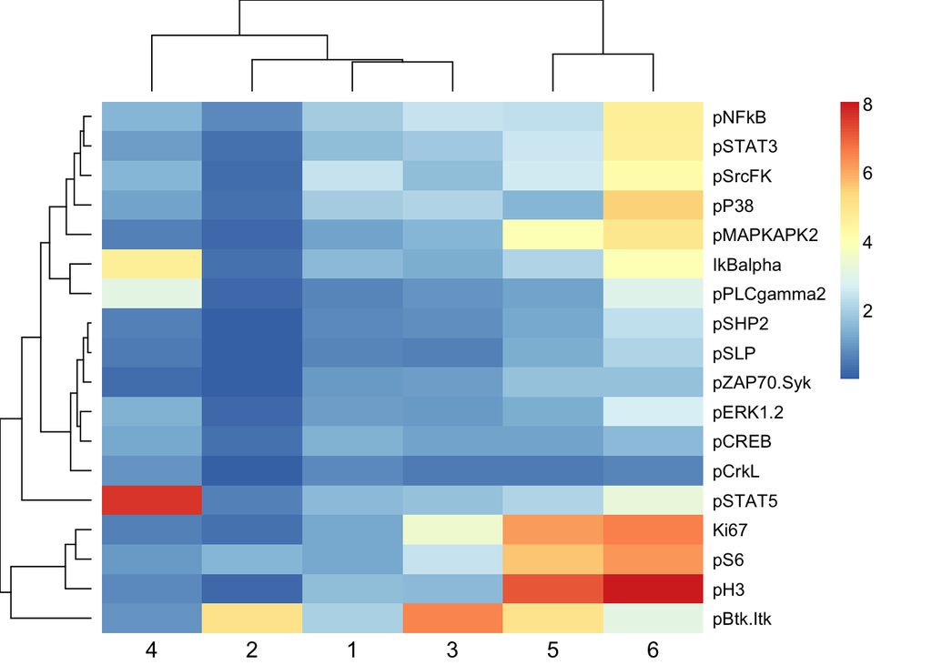

```r
expressionlevels = signalLevelHeatmap(data_agg, signal_level=max)
```

```r
columnOrder<-expressionlevels$colInd
```

Draw subpopulation proportion heatmap for all samples

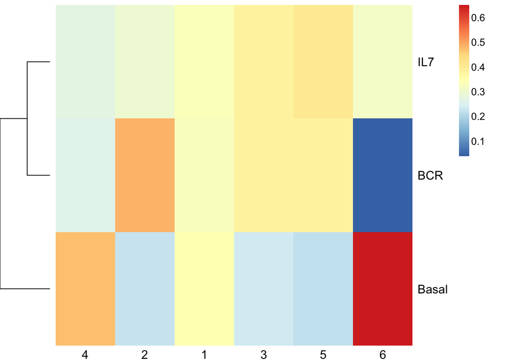

```r
subpopprop = clusterPropHeatmap(data_agg, Colv_order = columnOrder)
```

Obtain annotations of subpopulations

```r
subpop_names_top2 = clusterNames(data_agg, Num_TopFeatures = 2)
subpop_names_top2
```

```
## [1] "pCrkL-pCREB"       "pBtk.Itk-pS6"      "pBtk.Itk-Ki67"
## [4] "pSTAT5-pPLCgamma2" "pH3-Ki67"          "pP38-pH3"
```

```r
write.table(subpop_names_top2, "subpop_names_top2.txt", quote=FALSE,col.names=FALSE)
```

Generate packed circle plot of the subpopulations and samples.

The annotation from the previous step is used to label the circles. CountFilter is a parameter that is used to filter out estimated subpopulations with less cell events than the set threshold.

```r
packedCircleInput(data_agg, subpop_names_top2, CountFilter = 10, filename="zoomablePackedCirclesInput.txt")
```

Please open “zoomablePackedCirclesVisualization.html” in Firefox in Mac or Google Safari in Windows; these are the more stable browsers for viewing the packed circle plot. Please make sure that “zoomablePackedCirclesInput.txt” is in the same directory as the html file.